# Otras cuestiones

3/25/2021

## Forma funcional

## Descripción del problema

- ¿Debemos tomar logaritmos? ¿Incluir el cuadrado de algunas explicativas?

## Contrastes

- Contraste \(F\).
- RESET: contraste general de mala especificación.
- Contrastes de modelos no anidados.

## Observaciones perdidas

## Descripción del problema

- En algunas observaciones no tenemos los valores de algunas variables.

## Consecuencias

- ¿Qué ha provocado la pérdida de observaciones?
- Existen métodos de **imputación**, pero suelen ser complicados y poco generales.

## Muestras no aleatorias

## Descripción del problema (I)

- Muchos de los resultados que hemos visto dependen del supuesto **RLM.2**.
- En algunos casos, si se incumple **RLM.2** no tiene consecuencias importantes: **muestreo estratificado**.

## Descripción del problema (II)

Suele haber problemas más serios cuando:

- El muestreo se realiza en función de la variable dependiente.
- Hay una **dependencia** importante entre las observaciones de la muestra.

## Observaciones atípicas y observaciones influyentes

## Descripción del problema

- En una muestra hay observaciones que toman valores muy inusuales de las variables explicativas o de la variable dependiente.

## Detección

- Examen de los residuos.
- Gráficos de los residuos frente a las variables explicativas.

## Ejemplo (I)

Modelo de determinación de los precios de venta de las casas: \[ price = \beta_0 + \beta_1 sqrft + \beta_2 lotsize + \beta_3 bdrms + u \]

## Ejemplo (II)

Estimación por MCO:

```
##
## Call:
## lm(price ~ sqrft + lotsize + bdrms, data = hprice1)
##
## Coefficients:
##                Estimate  Std. Error t value  Pr(>|t|)
## (Intercept) -2.1770e+01  2.9475e+01 -0.7386  0.462208
## sqrft        1.2278e-01  1.3237e-02  9.2751 1.658e-14 ***
## lotsize      2.0677e-03  6.4213e-04  3.2201  0.001823 **
## bdrms        1.3853e+01  9.0101e+00  1.5374  0.127945
## ---
## Signif. codes:  0 '***' 0.001 '**' 0.01 '*' 0.05 '.' 0.1 ' ' 1
##
## Residual standard error: 59.83 on 84 degrees of freedom
## Multiple R-squared:  0.6724, Adjusted R-squared:  0.6607
## F-statistic: 57.46 on 3 and 84 DF,  p-value: < 2.2e-16
```

## Ejemplo (III)

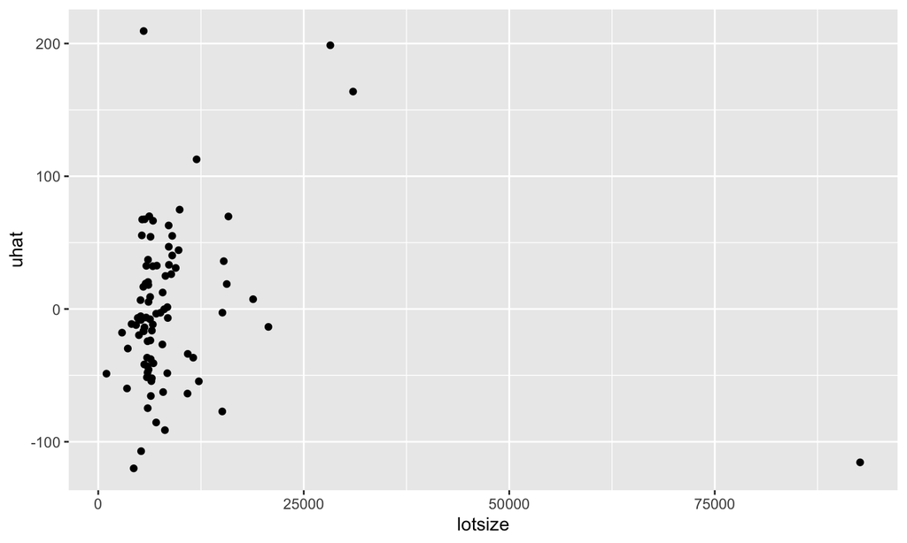

## Ejemplo (IV)

Excluimos la casa atípica:

```
##
## Call:
## lm(price ~ sqrft + lotsize + bdrms, data = hprice1b)
##
## Coefficients:
##                Estimate  Std. Error t value  Pr(>|t|)
## (Intercept) -28.3011703  25.1493826 -1.1253  0.263696
## sqrft         0.0864946   0.0129486  6.6799 2.549e-09 ***
## lotsize       0.0091949   0.0013627  6.7478 1.884e-09 ***
## bdrms        20.4819200   7.7671170  2.6370  0.009983 **
## ---
## Signif. codes:  0 '***' 0.001 '**' 0.01 '*' 0.05 '.' 0.1 ' ' 1
##
## Residual standard error: 51 on 83 degrees of freedom
## Multiple R-squared:  0.7646, Adjusted R-squared:  0.7561
## F-statistic: 89.89 on 3 and 83 DF,  p-value: < 2.2e-16
```

## Ejemplo (V)

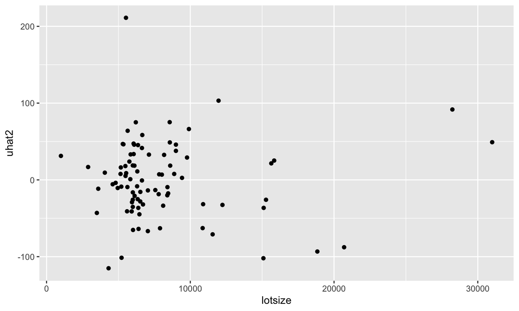

## Ejemplo (VI)

Al eliminar la observación influyente, no se detectan problemas de heteroscedasticidad.

```
##
##  LM test for heteroskedasticity
##
## data:  Auxiliary regression of squared residuals from:
##   lm(price ~ sqrft + lotsize + bdrms, data = hprice1b)
## on all covariates.
##
##
## F = 0.85717, df1 = 3, df2 = 83, p-value = 0.4667
```